# DATASET: Loan Default Prediction Dataset

Dataset Link: https://www.kaggle.com/datasets/marcbuji/loan-default-prediction/data

Purpose: the purpose of the analysis is to build a predictive model that estimates the likelihood of loan default based on various parameters. This helps lenders:

Manage risk effectively. Plan finances by estimating potential losses. Segment customers according to risk profiles. Ensure compliance with regulations. Take proactive measures to reduce losses associated with defaults.

Questions: What is the distribution of loan defaults? How do demographic factors differ between defaulted and non-defaulted borrowers? What are the patterns in loan amounts and interest rates? Are there correlations between features like debt-to-income ratio and default likelihood? How do default rates vary by geographic location and over time? What are the financial profiles of borrowers and their relation to defaults? How do loan characteristics impact default rates? Are there differences in default rates based on validation or file status? What are the common reasons for loan applications and their correlation with defaults?Objective or goal:About Dataset Banks run into losses when a customer doesn't pay their loans on time. Because of this, every year, banks have losses in crores, and this also impacts the country's economic growth to a large extent. We look at various attributes such as funded amount, location, loan, balance, etc., to predict if a person will be a loan defaulter or not. To build a model to solve this problem, Grant Group Funding has a dataset of 87,501 rows and 30 columns based on a client in banking sector. ID: Unique ID Asst_Reg: Value of all the assets registered under the borrowers name GGGrade: Grant Group Grade Experience: Total year of work experience of the borrower Validation: Validation status of the borrower Yearly Income : Total yearly income of the borrower Home Status: Borrower living status Unpaid 2 years : No. of times the Borrower has defaulted in last two years "Already Defaulted : Number of other loans the borrower was default" Designation : Designation of Borrower Debt to Income : Debt to Income ratio Postal Code : Postal code of borrower Lend Amount : Total funded amount to borrower "Deprecatory Records: An entry that may be considered negative by lenders because it indicates risk and hurts your ability to qualify for credit or other services" Interest Charged : Interest charged on total amount Usage Rate: Processing Charges on the Loan Amount Inquiries: Inquiries in Last 6 Months Present Balance: Current balance in the borrower account Gross Collection: The gross amount payable by way of Settlement or judgment in respect of the Claims, excluding any costs Sub GGGrade: Sub Grant Group Grade File Status: Status of the loan file State: State to which borrower belong Account Open: Total number of open accounts in the name of Borrower Total Unpaid CL: Unpaid dues on all the other loans Duration: Duration for the amount is funded to borrower Unpaid Amount: Unpaid balance on the credit card Reason: Reason for loan application Claim Type: Amongst all Application type what is the borrower Claim Type I - Individual Account , J - Joint Account" Due Fee: Charges incurred if the payment on loan amount is delayed Loan/No Loan: Target Variable

```python
import pandas as pd
import numpy as np
import seaborn as sns
import matplotlib.pyplot as plt
```

```python
data = pd.read_csv("C:/Users/ADMIN/Downloads/archive (1)/Loan Default Prediction Dataset.csv")
```

```python
data.head()
```

|  | ID | Asst_Reg | GGGrade | Experience | Validation | Yearly_Income | Home_Status | Unpaid_2_years | Already_Defaulted | Designation | ... | File_Status | State | Account_Open | Total_Unpaid_CL | Duration | Unpaid_Amount | Reason | Claim_Type | Due_Fee | Default |
| --- | --- | --- | --- | --- | --- | --- | --- | --- | --- | --- | --- | --- | --- | --- | --- | --- | --- | --- | --- | --- | --- |
| 0 | 95074 | 421802 | II | >10yrs | Vfied | 633600.00 | MORTGAGE | 0 | 0 | GLENDALE NISSAN | ... | fully paid | California | 17 | 58598.0 | 3 years | 31216.05 | debt consolidation | I | 0.0 | 0 |
| 1 | 134131 | 3964312 | IV | 7yrs | Source Verified | 85483.20 | RENT | 0 | 0 | Business Teacher | ... | whole | NC | 15 | 18924.0 | 5 years | 11660.49 | debt consolidation | I | 0.0 | 0 |
| 2 | 92602 | 4247560 | III | <1yr | Source Verified | 79200.00 | RENT | 0 | 0 | driver | ... | whole | Florida | 7 | 15604.0 | 5 years | 5637.87 | major purchase | I | 0.0 | 0 |
| 3 | 22591 | 197179 | III | <1yr | Vfied | 61600.00 | RENT | 0 | 0 | AvePoint | ... | fully paid | NewJersey | 9 | 22410.0 | 3 years | 15607.17 | major purchase | I | 0.0 | 1 |
| 4 | 125060 | 4646684 | V | 2yrs | Source Verified | 68053.92 | RENT | 0 | 0 | Lead Tester | ... | fully paid | LA | 10 | 36022.0 | 5 years | 27472.86 | debt consolidation | I | 0.0 | 0 |

5 rows × 30 columns

```python
data.tail()
```

|  | ID | Asst_Reg | GGGrade | Experience | Validation | Yearly_Income | Home_Status | Unpaid_2_years | Already_Defaulted | Designation | ... | File_Status | State | Account_Open | Total_Unpaid_CL | Duration | Unpaid_Amount | Reason | Claim_Type | Due_Fee | Default |
| --- | --- | --- | --- | --- | --- | --- | --- | --- | --- | --- | --- | --- | --- | --- | --- | --- | --- | --- | --- | --- | --- |
| 87495 | 120884 | 4535984 | II | >10yrs | Not Vfied | 75680.00 | RENT | 0 | 0 | Engineer Support II | ... | whole | MI | 12 | 32702.0 | 3 years | 10012.05 | debt consolidation | I | 0.0 | 0 |
| 87496 | 33259 | 2624710 | IV | 3yrs | Source Verified | 90423.52 | RENT | 0 | 0 | Dental Hygienist | ... | whole | MA | 23 | 32204.0 | 5 years | 24921.54 | debt consolidation | I | 0.0 | 0 |
| 87497 | 102153 | 5966919 | II | >10yrs | Source Verified | 91520.00 | MORTGAGE | 0 | 0 | Interface Coordinator | ... | fully paid | CT | 8 | 29050.0 | 3 years | 14517.90 | debt consolidation | I | 0.0 | 0 |
| 87498 | 115343 | 2630667 | III | 1yrs | Source Verified | 61600.00 | MORTGAGE | 0 | 0 | PARTS CLERK | ... | whole | PA | 11 | 24900.0 | 3 years | 8454.24 | debt consolidation | I | 0.0 | 0 |
| 87499 | 104968 | 6637289 | III | 2yrs | Vfied | NaN | RENT | 0 | 0 | Outside sales rep | ... | whole | California | 7 | 21746.0 | 5 years | 8717.58 | debt consolidation | I | 0.0 | 0 |

5 rows × 30 columns

```python
data.shape
```

```
(87500, 30)
```

```python
data.dtypes
```

```
ID                       int64
Asst_Reg                 int64
GGGrade                 object
Experience              object
Validation              object
Yearly_Income          float64
Home_Status             object
Unpaid_2_years           int64
Already_Defaulted        int64
Designation             object
Debt_to_Income         float64
Postal_Code            float64
Lend_Amount            float64
Deprecatory_Records      int64
Interest_Charged       float64
Usage_Rate             float64
Inquiries                int64
Present_Balance        float64
Gross_Collection       float64
Sub_GGGrade              int64
File_Status             object
State                   object
Account_Open             int64
Total_Unpaid_CL        float64
Duration                object
Unpaid_Amount          float64
Reason                  object
Claim_Type              object
Due_Fee                float64
Default                  int64
dtype: object
```

```python
data.describe()
```

|  | ID | Asst_Reg | Yearly_Income | Unpaid_2_years | Already_Defaulted | Debt_to_Income | Postal_Code | Lend_Amount | Deprecatory_Records | Interest_Charged | Usage_Rate | Inquiries | Present_Balance | Gross_Collection | Sub_GGGrade | Account_Open | Total_Unpaid_CL | Unpaid_Amount | Due_Fee | Default |
| --- | --- | --- | --- | --- | --- | --- | --- | --- | --- | --- | --- | --- | --- | --- | --- | --- | --- | --- | --- | --- |
| count | 87500.000000 | 8.750000e+04 | 8.192500e+04 | 87500.000000 | 87500.000000 | 84011.000000 | 86111.000000 | 87500.000000 | 87500.000000 | 87500.000000 | 87500.000000 | 87500.000000 | 8.750000e+04 | 87500.000000 | 87500.000000 | 87500.00000 | 8.331400e+04 | 8.264800e+04 | 87500.000000 | 87500.000000 |
| mean | 83946.253509 | 3.798914e+06 | 1.348596e+05 | 0.332937 | 0.005726 | 30.942660 | 51155.385491 | 25920.535680 | 0.202400 | 16.518375 | 95.517348 | 0.670640 | 2.363895e+05 | 39.461697 | 22.024891 | 12.77944 | 5.326864e+04 | 2.955649e+04 | 0.316407 | 0.188709 |
| std | 36100.102950 | 2.289038e+06 | 9.882473e+04 | 0.876080 | 0.083505 | 14.079813 | 31211.229930 | 14433.837213 | 0.646414 | 4.902011 | 40.554035 | 0.959572 | 2.550568e+05 | 391.919578 | 6.452697 | 5.37116 | 5.325551e+04 | 3.745625e+04 | 3.546087 | 0.391279 |
| min | 21560.000000 | 2.484700e+04 | 8.800000e+03 | 0.000000 | 0.000000 | 0.000000 | 1000.000000 | 1710.000000 | 0.000000 | 8.000000 | 0.000000 | 0.000000 | 0.000000e+00 | 0.000000 | 11.000000 | 2.00000 | 3.320000e+02 | 0.000000e+00 | 0.000000 | 0.000000 |
| 25% | 52616.750000 | 1.483874e+06 | 8.324659e+04 | 0.000000 | 0.000000 | 20.428800 | 22900.000000 | 15048.000000 | 0.000000 | 12.310000 | 66.048000 | 0.000000 | 5.173493e+04 | 0.000000 | 17.000000 | 9.00000 | 2.324000e+04 | 1.144674e+04 | 0.000000 | 0.000000 |
| 50% | 83900.000000 | 4.132010e+06 | 1.144000e+05 | 0.000000 | 0.000000 | 30.139200 | 47700.000000 | 23940.000000 | 0.000000 | 16.490000 | 97.008000 | 0.000000 | 1.388062e+05 | 0.000000 | 21.000000 | 12.00000 | 3.967400e+04 | 2.089278e+04 | 0.000000 | 0.000000 |
| 75% | 115261.250000 | 5.952909e+06 | 1.601600e+05 | 0.000000 | 0.000000 | 40.908000 | 80200.000000 | 34200.000000 | 0.000000 | 20.770000 | 126.592000 | 1.000000 | 3.534755e+05 | 0.000000 | 26.000000 | 16.00000 | 6.640000e+04 | 3.644908e+04 | 0.000000 | 0.000000 |
| max | 146559.000000 | 7.351847e+06 | 8.264031e+06 | 18.000000 | 6.000000 | 639.290400 | 99900.000000 | 59850.000000 | 86.000000 | 25.000000 | 1534.756000 | 8.000000 | 5.629234e+06 | 26308.470000 | 45.000000 | 83.00000 | 1.710630e+06 | 1.338778e+06 | 169.050000 | 1.000000 |

```python
data.columns
```

```
Index(['ID', 'Asst_Reg', 'GGGrade', 'Experience', 'Validation',
       'Yearly_Income', 'Home_Status', 'Unpaid_2_years', 'Already_Defaulted',
       'Designation', 'Debt_to_Income', 'Postal_Code', 'Lend_Amount',
       'Deprecatory_Records', 'Interest_Charged', 'Usage_Rate', 'Inquiries',
       'Present_Balance', 'Gross_Collection', 'Sub_GGGrade', 'File_Status',
       'State', 'Account_Open', 'Total_Unpaid_CL', 'Duration', 'Unpaid_Amount',
       'Reason', 'Claim_Type', 'Due_Fee', 'Default'],
      dtype='object')
```

```python
data.nunique()
```

```
ID                     87500
Asst_Reg               83966
GGGrade                    7
Experience                11
Validation                 3
Yearly_Income           6871
Home_Status                5
Unpaid_2_years            18
Already_Defaulted          7
Designation            40348
Debt_to_Income          3964
Postal_Code              865
Lend_Amount             1298
Deprecatory_Records       18
Interest_Charged        1701
Usage_Rate              1088
Inquiries                  8
Present_Balance        73819
Gross_Collection        1678
Sub_GGGrade               35
File_Status                2
State                     49
Account_Open              59
Total_Unpaid_CL         4385
Duration                   2
Unpaid_Amount          34679
Reason                    13
Claim_Type                 2
Due_Fee                  608
Default                    2
dtype: int64
```

```python
data['Experience'].unique()
```

```
array(['>10yrs', '7yrs', '<1yr', '2yrs', '1yrs', '4yrs', '9yrs', '6yrs',
       '5yrs', '8yrs', '3yrs'], dtype=object)
```

```python
#finding the number of missing values
data.isnull().sum()
```

```
ID                        0
Asst_Reg                  0
GGGrade                   0
Experience                0
Validation                0
Yearly_Income          5575
Home_Status               0
Unpaid_2_years            0
Already_Defaulted         0
Designation            1414
Debt_to_Income         3489
Postal_Code            1389
Lend_Amount               0
Deprecatory_Records       0
Interest_Charged          0
Usage_Rate                0
Inquiries                 0
Present_Balance           0
Gross_Collection          0
Sub_GGGrade               0
File_Status               0
State                     0
Account_Open              0
Total_Unpaid_CL        4186
Duration                  0
Unpaid_Amount          4852
Reason                    0
Claim_Type                0
Due_Fee                   0
Default                   0
dtype: int64
```

```python
train = data.drop(['ID','Asst_Reg','Validation','Designation','Postal_Code','Interest_Charged','Usage_Rate','Gross_Collection','Sub_GGGrade','File_Status','State','Account_Open','Duration','Claim_Type'],axis=1)
```

```python
train.columns
```

```
Index(['GGGrade', 'Experience', 'Yearly_Income', 'Home_Status',
       'Unpaid_2_years', 'Already_Defaulted', 'Debt_to_Income', 'Lend_Amount',
       'Deprecatory_Records', 'Inquiries', 'Present_Balance',
       'Total_Unpaid_CL', 'Unpaid_Amount', 'Reason', 'Due_Fee', 'Default'],
      dtype='object')
```

```python
train.isnull().sum()
```

```
GGGrade                   0
Experience                0
Yearly_Income          5575
Home_Status               0
Unpaid_2_years            0
Already_Defaulted         0
Debt_to_Income         3489
Lend_Amount               0
Deprecatory_Records       0
Inquiries                 0
Present_Balance           0
Total_Unpaid_CL        4186
Unpaid_Amount          4852
Reason                    0
Due_Fee                   0
Default                   0
dtype: int64
```

```python
import pandas as pd

# Load the dataset
data_df = pd.read_csv("C:/Users/ADMIN/Downloads/archive (1)/Loan Default Prediction Dataset.csv")

# Columns with null values
columns_with_null = ['Yearly_Income', 'Debt_to_Income', 'Total_Unpaid_CL', 'Unpaid_Amount']

# Filter rows with null values in specified columns
filtered_data = data_df[data_df[columns_with_null].isnull().any(axis=1)]

# Get statistics for filtered columns
statistics = filtered_data[columns_with_null].describe().round(2)
print(statistics)
```

```
       Yearly_Income  Debt_to_Income  Total_Unpaid_CL  Unpaid_Amount
count       11152.00        13238.00         12541.00       11875.00
mean       134605.83           31.16         52950.75       30312.38
std        112297.23           13.89         51419.10       39831.10
min         13128.97            0.30           498.00           0.00
25%         84480.00           20.76         22908.00       11557.04
50%        114400.00           30.34         39840.00       20944.08
75%        158400.00           41.18         66234.00       36914.62
max       5491200.00           69.70       1203415.34     1012326.84
```

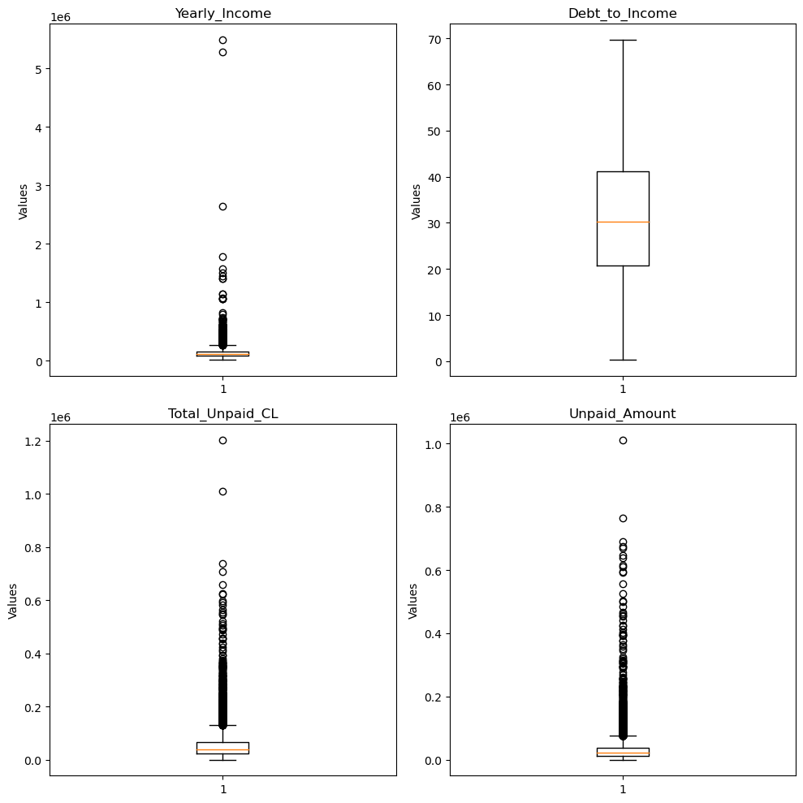

```python
import pandas as pd
import matplotlib.pyplot as plt

# Load the dataset
data_df = pd.read_csv("C:/Users/ADMIN/Downloads/archive (1)/Loan Default Prediction Dataset.csv")

# Columns with null values
columns_with_null = ['Yearly_Income', 'Debt_to_Income', 'Total_Unpaid_CL', 'Unpaid_Amount']

# Filter rows with null values in specified columns
filtered_data = data_df[data_df[columns_with_null].isnull().any(axis=1)]

# Create separate box plots for each column
plt.figure(figsize=(10, 10))
for i, column in enumerate(columns_with_null, start=1):
    plt.subplot(2, 2, i)
    plt.boxplot(filtered_data[column].dropna())
    plt.title(column)
    plt.ylabel("Values")
plt.tight_layout()  # Adjust subplot layout
plt.show()
```

since there are many outliers to the right of Yearly income, Total_Unpaid CL, Unpaid Amt plots they are skewed hence we replace their null values by their medians and in the case of plot of DTI we see a normal distribution. Hence we replace its null values by the mean value of that column

```python
import pandas as pd

# Specify the columns you want to replace null values with median
columns_to_replace = ['Yearly_Income','Total_Unpaid_CL','Unpaid_Amount']

# Replace null values with mean
for column in columns_to_replace:
    median_value = train[column].median()  # Calculate the median for the column
    train[column].fillna(median_value, inplace=True)  # Replace null values with median

# Now the changes are saved in the 'train' dataset variable
```

```python
import pandas as pd

# Specify the columns you want to replace null values with mean
columns_to_replace = ['Debt_to_Income']

# Replace null values with median
for column in columns_to_replace:
    mean_value = train[column].mean()  # Calculate the mean for the column
    train[column].fillna(mean_value, inplace=True)  # Replace null values with mean

# Now the changes are saved in the 'train' dataset variable
```

```python
data.describe()
```

|  | ID | Asst_Reg | Yearly_Income | Unpaid_2_years | Already_Defaulted | Debt_to_Income | Postal_Code | Lend_Amount | Deprecatory_Records | Interest_Charged | Usage_Rate | Inquiries | Present_Balance | Gross_Collection | Sub_GGGrade | Account_Open | Total_Unpaid_CL | Unpaid_Amount | Due_Fee | Default |
| --- | --- | --- | --- | --- | --- | --- | --- | --- | --- | --- | --- | --- | --- | --- | --- | --- | --- | --- | --- | --- |
| count | 87500.000000 | 8.750000e+04 | 8.192500e+04 | 87500.000000 | 87500.000000 | 84011.000000 | 86111.000000 | 87500.000000 | 87500.000000 | 87500.000000 | 87500.000000 | 87500.000000 | 8.750000e+04 | 87500.000000 | 87500.000000 | 87500.00000 | 8.331400e+04 | 8.264800e+04 | 87500.000000 | 87500.000000 |
| mean | 83946.253509 | 3.798914e+06 | 1.348596e+05 | 0.332937 | 0.005726 | 30.942660 | 51155.385491 | 25920.535680 | 0.202400 | 16.518375 | 95.517348 | 0.670640 | 2.363895e+05 | 39.461697 | 22.024891 | 12.77944 | 5.326864e+04 | 2.955649e+04 | 0.316407 | 0.188709 |
| std | 36100.102950 | 2.289038e+06 | 9.882473e+04 | 0.876080 | 0.083505 | 14.079813 | 31211.229930 | 14433.837213 | 0.646414 | 4.902011 | 40.554035 | 0.959572 | 2.550568e+05 | 391.919578 | 6.452697 | 5.37116 | 5.325551e+04 | 3.745625e+04 | 3.546087 | 0.391279 |
| min | 21560.000000 | 2.484700e+04 | 8.800000e+03 | 0.000000 | 0.000000 | 0.000000 | 1000.000000 | 1710.000000 | 0.000000 | 8.000000 | 0.000000 | 0.000000 | 0.000000e+00 | 0.000000 | 11.000000 | 2.00000 | 3.320000e+02 | 0.000000e+00 | 0.000000 | 0.000000 |
| 25% | 52616.750000 | 1.483874e+06 | 8.324659e+04 | 0.000000 | 0.000000 | 20.428800 | 22900.000000 | 15048.000000 | 0.000000 | 12.310000 | 66.048000 | 0.000000 | 5.173493e+04 | 0.000000 | 17.000000 | 9.00000 | 2.324000e+04 | 1.144674e+04 | 0.000000 | 0.000000 |
| 50% | 83900.000000 | 4.132010e+06 | 1.144000e+05 | 0.000000 | 0.000000 | 30.139200 | 47700.000000 | 23940.000000 | 0.000000 | 16.490000 | 97.008000 | 0.000000 | 1.388062e+05 | 0.000000 | 21.000000 | 12.00000 | 3.967400e+04 | 2.089278e+04 | 0.000000 | 0.000000 |
| 75% | 115261.250000 | 5.952909e+06 | 1.601600e+05 | 0.000000 | 0.000000 | 40.908000 | 80200.000000 | 34200.000000 | 0.000000 | 20.770000 | 126.592000 | 1.000000 | 3.534755e+05 | 0.000000 | 26.000000 | 16.00000 | 6.640000e+04 | 3.644908e+04 | 0.000000 | 0.000000 |
| max | 146559.000000 | 7.351847e+06 | 8.264031e+06 | 18.000000 | 6.000000 | 639.290400 | 99900.000000 | 59850.000000 | 86.000000 | 25.000000 | 1534.756000 | 8.000000 | 5.629234e+06 | 26308.470000 | 45.000000 | 83.00000 | 1.710630e+06 | 1.338778e+06 | 169.050000 | 1.000000 |

```python
train.describe()
```

|  | Yearly_Income | Unpaid_2_years | Already_Defaulted | Debt_to_Income | Lend_Amount | Deprecatory_Records | Inquiries | Present_Balance | Total_Unpaid_CL | Unpaid_Amount | Due_Fee | Default |
| --- | --- | --- | --- | --- | --- | --- | --- | --- | --- | --- | --- | --- |
| count | 8.750000e+04 | 87500.000000 | 87500.000000 | 87500.000000 | 87500.000000 | 87500.000000 | 87500.000000 | 8.750000e+04 | 8.750000e+04 | 8.750000e+04 | 87500.000000 | 87500.000000 |
| mean | 1.335561e+05 | 0.332937 | 0.005726 | 30.942660 | 25920.535680 | 0.202400 | 0.670640 | 2.363895e+05 | 5.261827e+04 | 2.907608e+04 | 0.316407 | 0.188709 |
| std | 9.575509e+04 | 0.876080 | 0.083505 | 13.796243 | 14433.837213 | 0.646414 | 0.959572 | 2.550568e+05 | 5.204695e+04 | 3.645688e+04 | 3.546087 | 0.391279 |
| min | 8.800000e+03 | 0.000000 | 0.000000 | 0.000000 | 1710.000000 | 0.000000 | 0.000000 | 0.000000e+00 | 3.320000e+02 | 0.000000e+00 | 0.000000 | 0.000000 |
| 25% | 8.624000e+04 | 0.000000 | 0.000000 | 20.848800 | 15048.000000 | 0.000000 | 0.000000 | 5.173493e+04 | 2.407000e+04 | 1.194948e+04 | 0.000000 | 0.000000 |
| 50% | 1.144000e+05 | 0.000000 | 0.000000 | 30.912000 | 23940.000000 | 0.000000 | 0.000000 | 1.388062e+05 | 3.967400e+04 | 2.089278e+04 | 0.000000 | 0.000000 |
| 75% | 1.584000e+05 | 0.000000 | 0.000000 | 40.404000 | 34200.000000 | 0.000000 | 1.000000 | 3.534755e+05 | 6.440800e+04 | 3.509604e+04 | 0.000000 | 0.000000 |
| max | 8.264031e+06 | 18.000000 | 6.000000 | 639.290400 | 59850.000000 | 86.000000 | 8.000000 | 5.629234e+06 | 1.710630e+06 | 1.338778e+06 | 169.050000 | 1.000000 |

```python
train.isnull().sum()
```

```
GGGrade                0
Experience             0
Yearly_Income          0
Home_Status            0
Unpaid_2_years         0
Already_Defaulted      0
Debt_to_Income         0
Lend_Amount            0
Deprecatory_Records    0
Inquiries              0
Present_Balance        0
Total_Unpaid_CL        0
Unpaid_Amount          0
Reason                 0
Due_Fee                0
Default                0
dtype: int64
```

OUR DATA IS NOW CLEAN

```python
train.head()
```

|  | GGGrade | Experience | Yearly_Income | Home_Status | Unpaid_2_years | Already_Defaulted | Debt_to_Income | Lend_Amount | Deprecatory_Records | Inquiries | Present_Balance | Total_Unpaid_CL | Unpaid_Amount | Reason | Due_Fee | Default |
| --- | --- | --- | --- | --- | --- | --- | --- | --- | --- | --- | --- | --- | --- | --- | --- | --- |
| 0 | II | >10yrs | 633600.00 | MORTGAGE | 0 | 0 | 12.5496 | 42023.25 | 0 | 3 | 607161.90 | 58598.0 | 31216.05 | debt consolidation | 0.0 | 0 |
| 1 | IV | 7yrs | 85483.20 | RENT | 0 | 0 | 9.0048 | 38133.00 | 0 | 0 | 269234.06 | 18924.0 | 11660.49 | debt consolidation | 0.0 | 0 |
| 2 | III | <1yr | 79200.00 | RENT | 0 | 0 | 24.9144 | 17100.00 | 0 | 0 | 22476.53 | 15604.0 | 5637.87 | major purchase | 0.0 | 0 |
| 3 | III | <1yr | 61600.00 | RENT | 0 | 0 | 16.5816 | 5130.00 | 0 | 1 | 15242.09 | 22410.0 | 15607.17 | major purchase | 0.0 | 1 |
| 4 | V | 2yrs | 68053.92 | RENT | 0 | 0 | 40.0512 | 19665.00 | 0 | 1 | 65433.94 | 36022.0 | 27472.86 | debt consolidation | 0.0 | 0 |

```python
train.info()
```

```
<class 'pandas.core.frame.DataFrame'>
RangeIndex: 87500 entries, 0 to 87499
Data columns (total 16 columns):
 #   Column               Non-Null Count  Dtype
---  ------               --------------  -----
 0   GGGrade              87500 non-null  object
 1   Experience           87500 non-null  object
 2   Yearly_Income        87500 non-null  float64
 3   Home_Status          87500 non-null  object
 4   Unpaid_2_years       87500 non-null  int64
 5   Already_Defaulted    87500 non-null  int64
 6   Debt_to_Income       87500 non-null  float64
 7   Lend_Amount          87500 non-null  float64
 8   Deprecatory_Records  87500 non-null  int64
 9   Inquiries            87500 non-null  int64
 10  Present_Balance      87500 non-null  float64
 11  Total_Unpaid_CL      87500 non-null  float64
 12  Unpaid_Amount        87500 non-null  float64
 13  Reason               87500 non-null  object
 14  Due_Fee              87500 non-null  float64
 15  Default              87500 non-null  int64
dtypes: float64(7), int64(5), object(4)
memory usage: 10.7+ MB
```

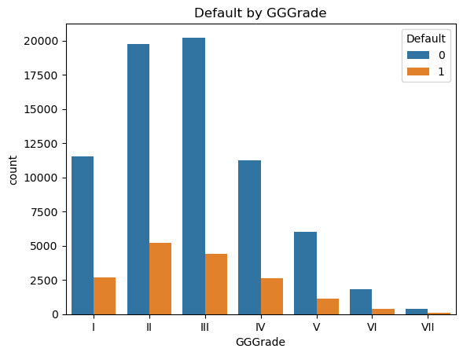

```python
# Relationship between 'GGGrade' and 'Default'
sorted_train = train.sort_values(by='GGGrade')
sns.countplot(data=sorted_train,x='GGGrade', hue='Default')
plt.title('Default by GGGrade')
plt.show()
```

GGGrade: "CGGrade: The GGGrade, or Grant Group Grade, appears to be a grading or rating system used by Grant Group Funding to assess the creditworthiness or risk level of borrowers. It likely indicates the borrower's credit score or credit rating assigned by the lending institution. The GGGrade helps the lender evaluate the likelihood of a borrower defaulting on a loan or their overall credit risk. Borrowers with higher GGGrades are considered more likely to repay their loans on time and are therefore more desirable from the lender's perspective

Default : Loan/No Loan: Target Variable '0' typically represents one class (i.e., No Loan, Not Defaulted) '1' typically represents the other class (i.e., Loan, Defaulted)

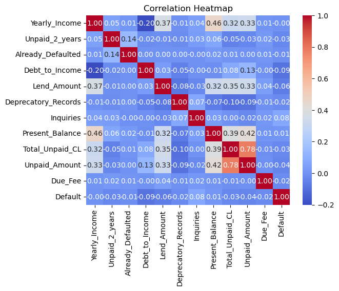

```python
# Correlation heatmap
corr = train.corr()
sns.heatmap(corr, annot=True, cmap='coolwarm', fmt=".2f")
plt.title('Correlation Heatmap')
plt.show()
```

This correlation matrix is a table which shows relationship between variables, each cell in the table shows relationship between any 2 variables. Summarises data for advanced analysis

We can observe that Total Unpaid CL and Unpaid Amount has a good positive correlation with each other compared to the rest

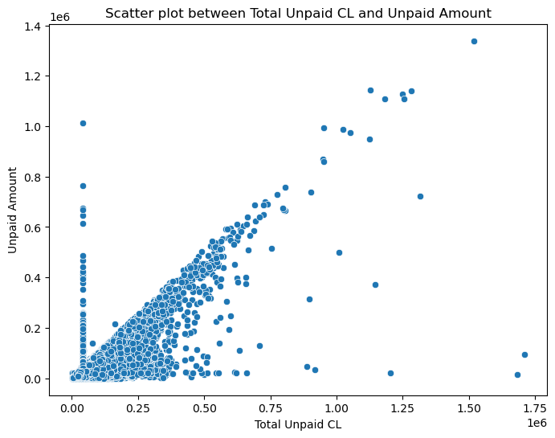

```python
plt.figure(figsize=(8, 6))
sns.scatterplot(data=train, x='Total_Unpaid_CL', y='Unpaid_Amount')
plt.title('Scatter plot between Total Unpaid CL and Unpaid Amount')
plt.xlabel('Total Unpaid CL')
plt.ylabel('Unpaid Amount')
plt.show()
```

A positive correlation between these variables will be indicated by a generally upward trend in the scatter plot.

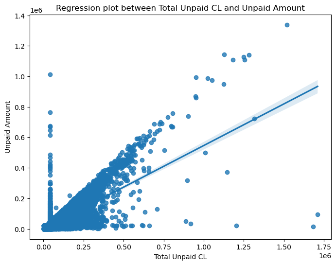

```python
plt.figure(figsize=(8, 6))
sns.regplot(data=train, x='Total_Unpaid_CL', y='Unpaid_Amount')
plt.title('Regression plot between Total Unpaid CL and Unpaid Amount')
plt.xlabel('Total Unpaid CL')
plt.ylabel('Unpaid Amount')
plt.show()
```

Fitting a regression line to the scatter plot to visualize the trend more clearly

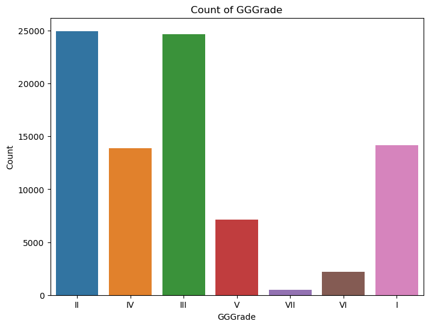

```python
# Count plot of 'GGGrade'
plt.figure(figsize=(8, 6))
sns.countplot(data=train, x='GGGrade')
plt.title('Count of GGGrade')
plt.xlabel('GGGrade')
plt.ylabel('Count')
plt.show()
```

The bank should seriously consider only giving loans to peeople with a good credit score or GGGrade in order to avoid unnecessary loan defaults. But here we can see that the loan company has many customers with lower GGGrades and very few higher GGGrades.

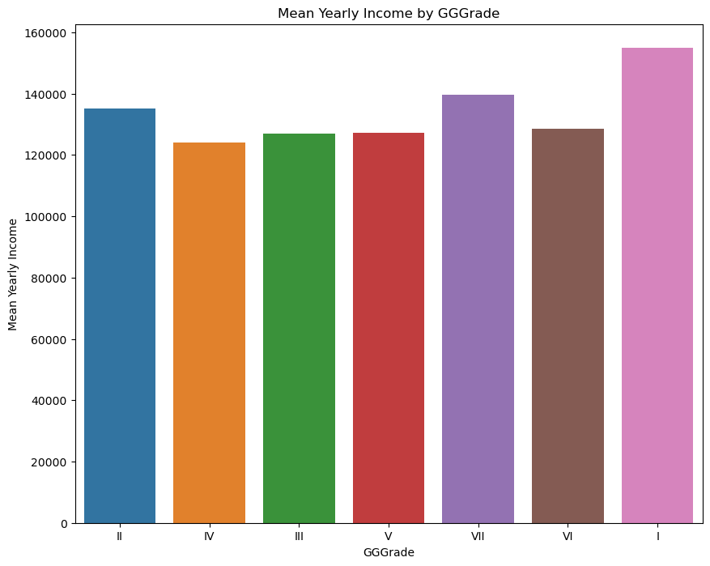

```python
plt.figure(figsize=(10, 8))
sns.barplot(data=train, x='GGGrade', y='Yearly_Income', ci=None)
plt.title('Mean Yearly Income by GGGrade')
plt.xlabel('GGGrade')
plt.ylabel('Mean Yearly Income')
plt.show()
```

The GGGrade does not simply increase with the yearly income of the people, it is affected due to the spending habits of people. So the loan company shoudld take into account the spending habits of people in order to avoid loan defaults. As we can see here the mean yearly income is almost same for every GGGrade customers in this graph

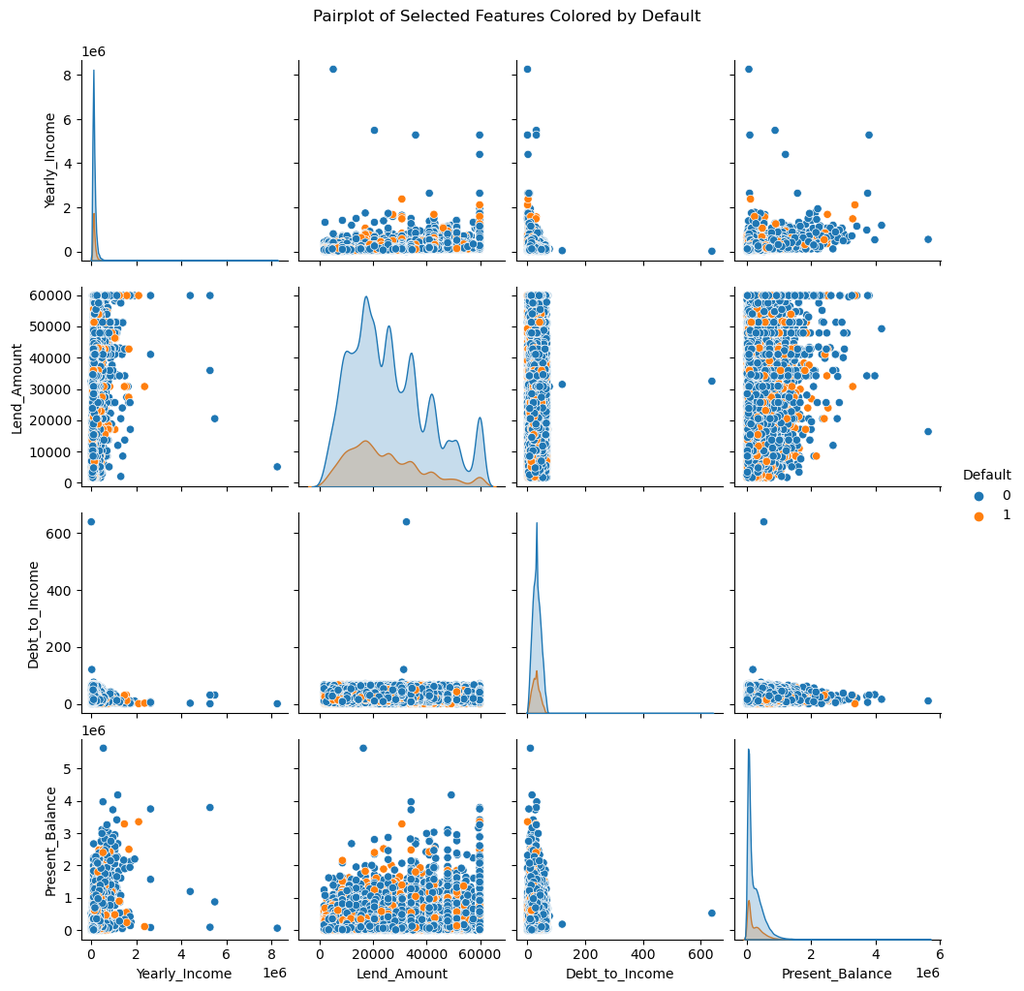

```python
# Pairplot of selected features colored by 'Default'
selected_features = ['Yearly_Income', 'Lend_Amount', 'Debt_to_Income', 'Present_Balance', 'Default']
sns.pairplot(train[selected_features], hue='Default', diag_kind='kde')
plt.suptitle('Pairplot of Selected Features Colored by Default', y=1.02)
plt.show()
```

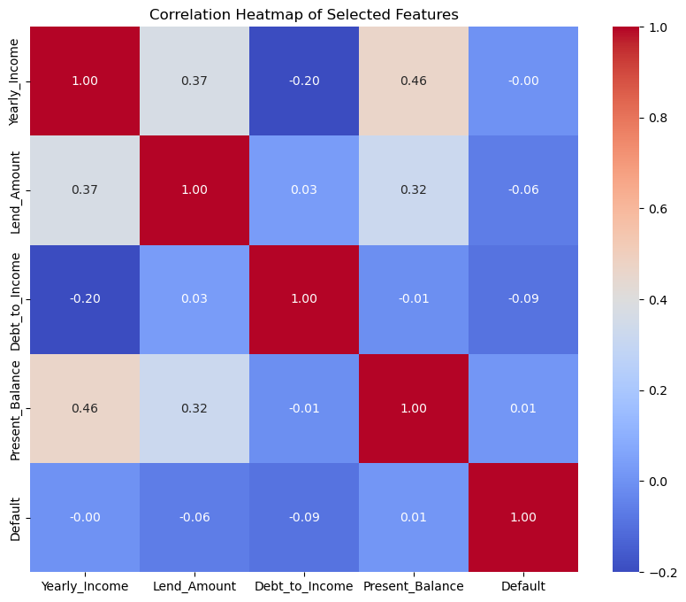

```python
# Heatmap of correlation between selected features
plt.figure(figsize=(10, 8))
corr = train[selected_features].corr()
sns.heatmap(corr, annot=True, cmap='coolwarm', fmt=".2f")
plt.title('Correlation Heatmap of Selected Features')
plt.show()
```

We can see that present balance and Yearly income has a better correlation between each other compared to other variables

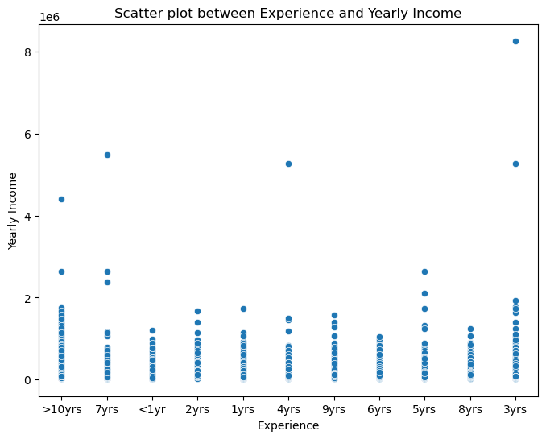

```python
plt.figure(figsize=(8, 6))
sns.scatterplot(data=train, x='Experience', y='Yearly_Income')
plt.title('Scatter plot between Experience and Yearly Income')
plt.xlabel('Experience')
plt.ylabel('Yearly Income')
plt.show()
```

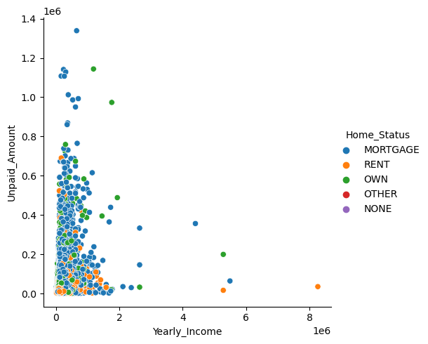

```python
sns.relplot(x='Yearly_Income',y='Unpaid_Amount',hue='Home_Status',data=train)
```